# Project - German Bank Loan

## Introduction:

In the banking sector, managing loan defaulters is a critical challenge for financial institutions. A German bank is grappling with this issue and seeks to develop a machine learning model to predict whether a customer will default on their loan. To achieve this, the bank has provided a dataset containing historical information on customers who have taken loans. This dataset includes various features such as employment duration, existing loans count, savings balance, percentage of income, age, and more, for each customer.

In this project, our goal is to explore this dataset and address several key questions. Firstly, we aim to understand the distribution and characteristics of the data through Exploratory Data Analysis (EDA). Next, we plan to build and compare different machine learning models to predict loan defaulters accurately. These models will be evaluated based on their performance metrics to determine the most effective approach for the bank.

### Interesting Questions

1. What is the distribution of defaulters vs. non-defaulters in the dataset?
2. Are there any noticeable trends or patterns in the data that distinguish defaulters from non-defaulters?
3. Which features (e.g., employment duration, savings balance, age) are most strongly correlated with loan default?
4. Can we build a predictive model that accurately predicts loan defaulters based on the available features?
5. How do different machine learning algorithms perform in predicting loan defaulters, and which one is the most effective for this dataset?
6. Can we identify any subgroups of customers (e.g., based on job type or purpose of loan) that are more prone to defaulting on their loans?
7. How do factors such as existing loans count, housing type, and dependents influence the likelihood of defaulting?
8. What are the key factors that the bank should focus on to reduce the risk of loan defaults in the future?

**Data Description**: The bank has historical information on relevant features for each customer such as employment duration, existing loans count, saving balance, percentage of income, age, default status.

The data set has 17 columns and 1000 rows. Columns are described below and each row is a customer.

- checking_balance - Amount of money available in account of customers
- months_loan_duration - Duration since loan taken
- credit_history - credit history of each customers
- purpose - Purpose why loan has been taken
- amount - Amount of loan taken
- savings_balance - Balance in account
- employment_duration - Duration of employment
- percent_of_income - Percentage of monthly income
- years_at_residence - Duration of current residence
- age - Age of customer
- other_credit - Any other credits taken
- housing- Type of housing, rent or own
- existing_loans_count - Existing count of loans
- job - Job type
- dependents - Any dependents on customer
- phone - Having phone or not
- default - Default status (Target column)

### Exploratory Data Analysis (EDA)

```python
# import libraries
import pandas as pd
import numpy as np
import seaborn as sns
import warnings
import matplotlib.pyplot as plt

warnings.filterwarnings("ignore")
```

#### Load the Dataset and Check the Structure of the Data

```python
df = pd.read_csv("credit.csv")
df.head(10)
```

|  | checking_balance | months_loan_duration | credit_history | purpose | amount | savings_balance | employment_duration | percent_of_income | years_at_residence | age | other_credit | housing | existing_loans_count | job | dependents | phone | default |
| --- | --- | --- | --- | --- | --- | --- | --- | --- | --- | --- | --- | --- | --- | --- | --- | --- | --- |
| 0 | < 0 DM | 6 | critical | furniture/appliances | 1169 | unknown | > 7 years | 4 | 4 | 67 | none | own | 2 | skilled | 1 | yes | no |
| 1 | 1 - 200 DM | 48 | good | furniture/appliances | 5951 | < 100 DM | 1 - 4 years | 2 | 2 | 22 | none | own | 1 | skilled | 1 | no | yes |
| 2 | unknown | 12 | critical | education | 2096 | < 100 DM | 4 - 7 years | 2 | 3 | 49 | none | own | 1 | unskilled | 2 | no | no |
| 3 | < 0 DM | 42 | good | furniture/appliances | 7882 | < 100 DM | 4 - 7 years | 2 | 4 | 45 | none | other | 1 | skilled | 2 | no | no |
| 4 | < 0 DM | 24 | poor | car | 4870 | < 100 DM | 1 - 4 years | 3 | 4 | 53 | none | other | 2 | skilled | 2 | no | yes |
| 5 | unknown | 36 | good | education | 9055 | unknown | 1 - 4 years | 2 | 4 | 35 | none | other | 1 | unskilled | 2 | yes | no |
| 6 | unknown | 24 | good | furniture/appliances | 2835 | 500 - 1000 DM | > 7 years | 3 | 4 | 53 | none | own | 1 | skilled | 1 | no | no |
| 7 | 1 - 200 DM | 36 | good | car | 6948 | < 100 DM | 1 - 4 years | 2 | 2 | 35 | none | rent | 1 | management | 1 | yes | no |
| 8 | unknown | 12 | good | furniture/appliances | 3059 | > 1000 DM | 4 - 7 years | 2 | 4 | 61 | none | own | 1 | unskilled | 1 | no | no |
| 9 | 1 - 200 DM | 30 | critical | car | 5234 | < 100 DM | unemployed | 4 | 2 | 28 | none | own | 2 | management | 1 | no | yes |

```python
df.info()
```

```
<class 'pandas.core.frame.DataFrame'>
RangeIndex: 1000 entries, 0 to 999
Data columns (total 17 columns):
 #   Column                Non-Null Count  Dtype
---  ------                --------------  -----
 0   checking_balance      1000 non-null   object
 1   months_loan_duration  1000 non-null   int64
 2   credit_history        1000 non-null   object
 3   purpose               1000 non-null   object
 4   amount                1000 non-null   int64
 5   savings_balance       1000 non-null   object
 6   employment_duration   1000 non-null   object
 7   percent_of_income     1000 non-null   int64
 8   years_at_residence    1000 non-null   int64
 9   age                   1000 non-null   int64
 10  other_credit          1000 non-null   object
 11  housing               1000 non-null   object
 12  existing_loans_count  1000 non-null   int64
 13  job                   1000 non-null   object
 14  dependents            1000 non-null   int64
 15  phone                 1000 non-null   object
 16  default               1000 non-null   object
dtypes: int64(7), object(10)
memory usage: 132.9+ KB
```

**Checking for missing values**

```python
df.isnull().sum()
```

```
checking_balance        0
months_loan_duration    0
credit_history          0
purpose                 0
amount                  0
savings_balance         0
employment_duration     0
percent_of_income       0
years_at_residence      0
age                     0
other_credit            0
housing                 0
existing_loans_count    0
job                     0
dependents              0
phone                   0
default                 0
dtype: int64
```

**Checking Unique values for categorical columns and preprocessing**

```python
categorical_columns = ["checking_balance", "credit_history", "purpose", "savings_balance", "employment_duration", "other_credit", "housing", "job", "phone", "default"]
numerical_columns = set(df.columns) - set(categorical_columns)
for column in categorical_columns:
    print(f"Unique values for {column}: {df[column].unique()}")
```

```
Unique values for checking_balance: ['< 0 DM' '1 - 200 DM' 'unknown' '> 200 DM']
Unique values for credit_history: ['critical' 'good' 'poor' 'perfect' 'very good']
Unique values for purpose: ['furniture/appliances' 'education' 'car' 'business' 'renovations' 'car0']
Unique values for savings_balance: ['unknown' '< 100 DM' '500 - 1000 DM' '> 1000 DM' '100 - 500 DM']
Unique values for employment_duration: ['> 7 years' '1 - 4 years' '4 - 7 years' 'unemployed' '< 1 year']
Unique values for other_credit: ['none' 'bank' 'store']
Unique values for housing: ['own' 'other' 'rent']
Unique values for job: ['skilled' 'unskilled' 'management' 'unemployed']
Unique values for phone: ['yes' 'no']
Unique values for default: ['no' 'yes']
```

We can see car and car0 values in purpose represents the same. Hence replacing car0 with car

```python
df['purpose'] = df['purpose'].replace('car0', 'car')
```

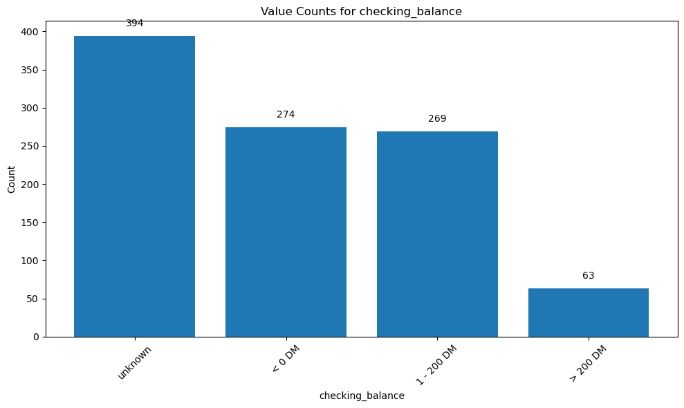

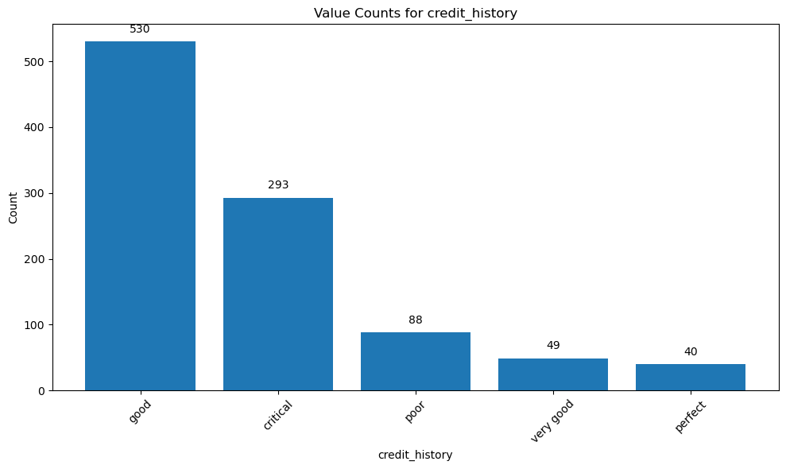

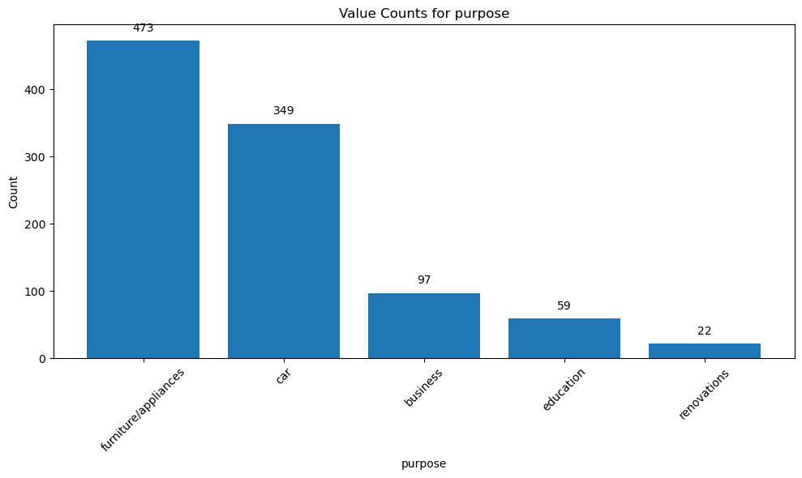

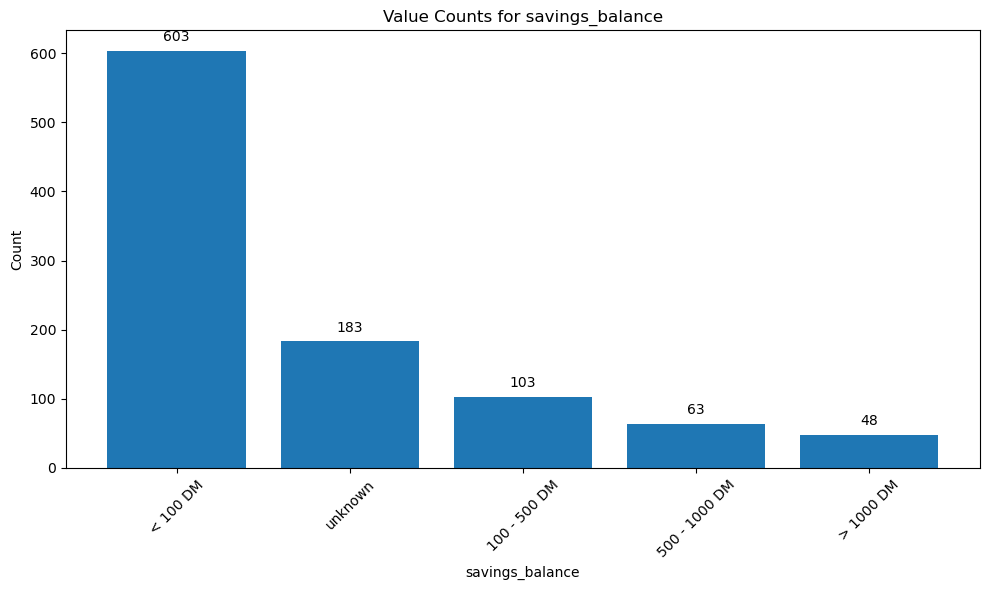

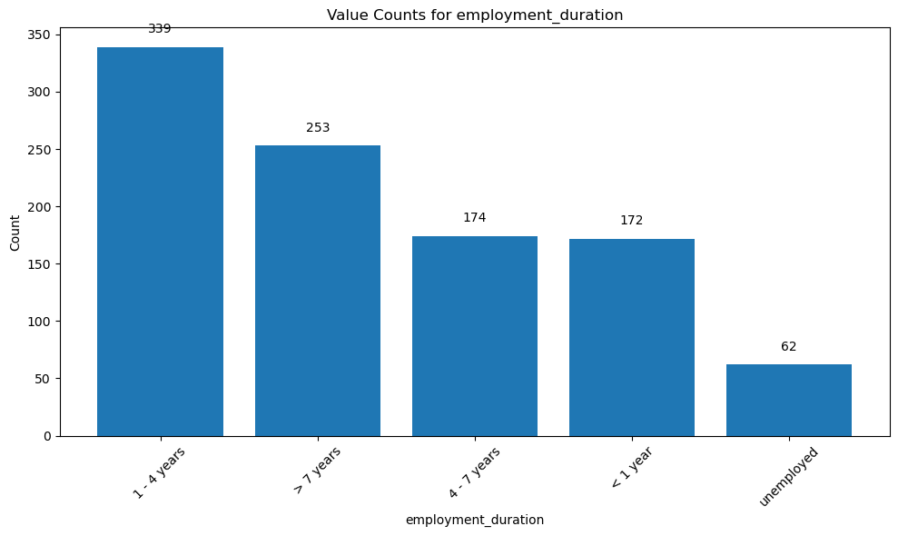

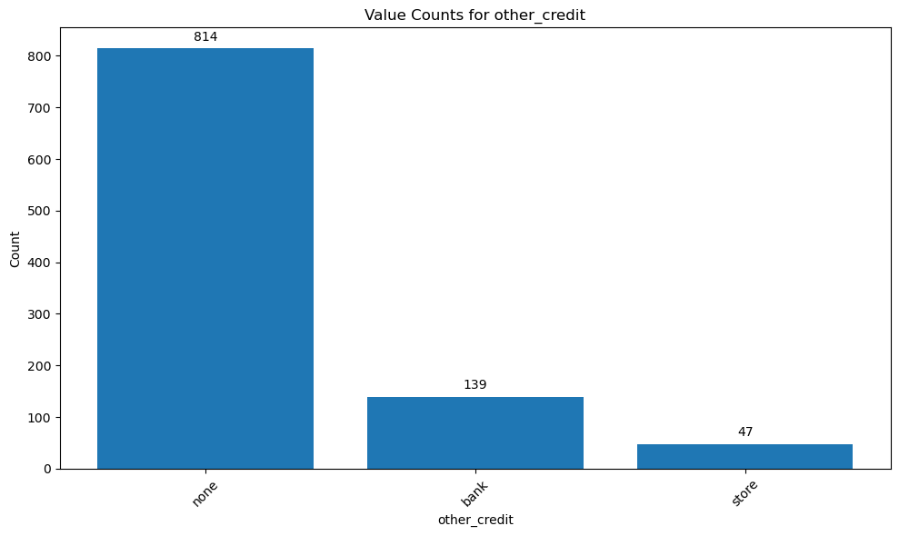

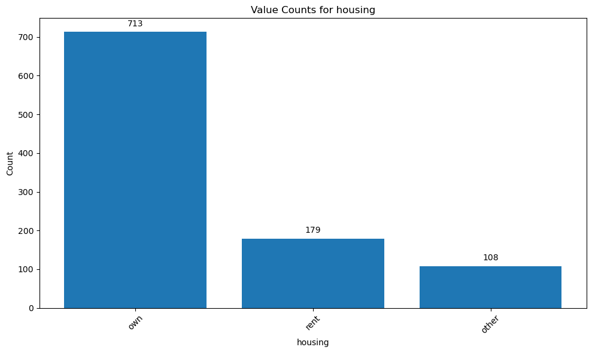

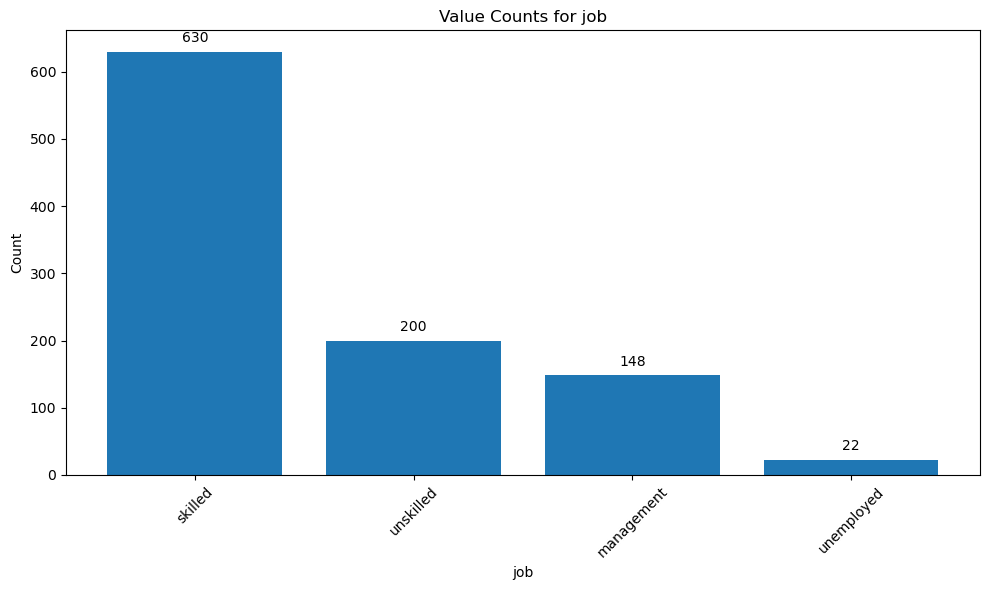

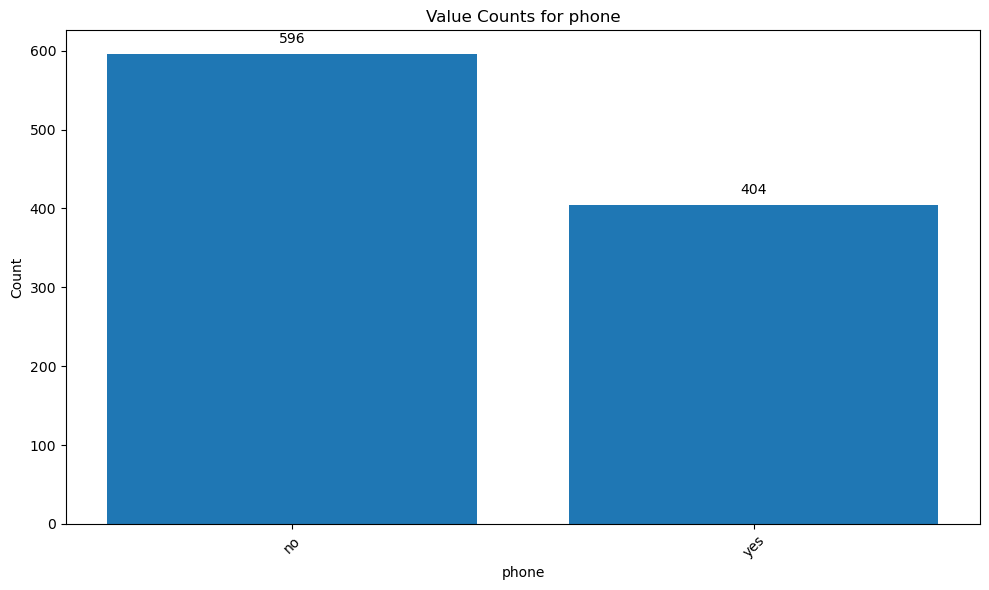

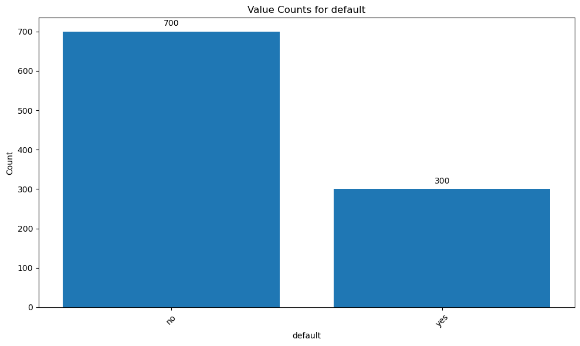

```python
for column in categorical_columns:
    # print(f"Unique values for {column}: {df[column].unique()}")
    # print(f"Value counts for {column}:")
    value_counts = df[column].value_counts()
    plt.figure(figsize=(10, 6))
    bars = plt.bar(value_counts.index, value_counts.values)
    for bar in bars:
        yval = bar.get_height()
        plt.text(bar.get_x() + bar.get_width()/2, yval + 10, int(yval), ha='center', va='bottom')
    plt.xlabel(column)
    plt.ylabel('Count')
    plt.title(f'Value Counts for {column}')
    plt.xticks(rotation=45)
    plt.tight_layout()
    plt.show()
```

**Checking for duplicate rows**

```python
print("Number of duplicated rows: ", df.duplicated().sum())
```

```
Number of duplicated rows:  0
```

**Exploring Stastictical Description**

```python
df.describe(include=['O', 'category']).T
```

|  | count | unique | top | freq |
| --- | --- | --- | --- | --- |
| checking_balance | 1000 | 4 | unknown | 394 |
| credit_history | 1000 | 5 | good | 530 |
| purpose | 1000 | 5 | furniture/appliances | 473 |
| savings_balance | 1000 | 5 | < 100 DM | 603 |
| employment_duration | 1000 | 5 | 1 - 4 years | 339 |
| other_credit | 1000 | 3 | none | 814 |
| housing | 1000 | 3 | own | 713 |
| job | 1000 | 4 | skilled | 630 |
| phone | 1000 | 2 | no | 596 |
| default | 1000 | 2 | no | 700 |

```python
df.describe(include=[np.number]).T
```

|  | count | mean | std | min | 25% | 50% | 75% | max |
| --- | --- | --- | --- | --- | --- | --- | --- | --- |
| months_loan_duration | 1000.0 | 20.903 | 12.058814 | 4.0 | 12.0 | 18.0 | 24.00 | 72.0 |
| amount | 1000.0 | 3271.258 | 2822.736876 | 250.0 | 1365.5 | 2319.5 | 3972.25 | 18424.0 |
| percent_of_income | 1000.0 | 2.973 | 1.118715 | 1.0 | 2.0 | 3.0 | 4.00 | 4.0 |
| years_at_residence | 1000.0 | 2.845 | 1.103718 | 1.0 | 2.0 | 3.0 | 4.00 | 4.0 |
| age | 1000.0 | 35.546 | 11.375469 | 19.0 | 27.0 | 33.0 | 42.00 | 75.0 |
| existing_loans_count | 1000.0 | 1.407 | 0.577654 | 1.0 | 1.0 | 1.0 | 2.00 | 4.0 |
| dependents | 1000.0 | 1.155 | 0.362086 | 1.0 | 1.0 | 1.0 | 1.00 | 2.0 |

**Encoding categories with only two possible outputs into 0 and 1**

```python
df_processed = df.copy()
df_processed['default'] = df['default'].replace({'yes': 1, 'no': 0})
df_processed['phone'] = df['phone'].replace({'yes': 1, 'no': 0})
categorical_columns.remove("phone")
categorical_columns.remove("default")
```

**Graphical representation for correlation between the varables and default**

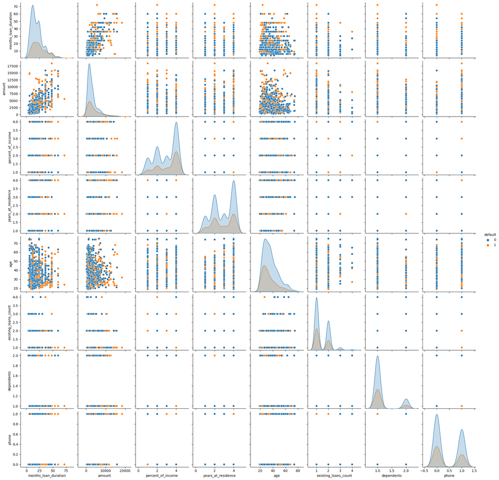

```python
sns.pairplot(data=df_processed, hue='default')
```

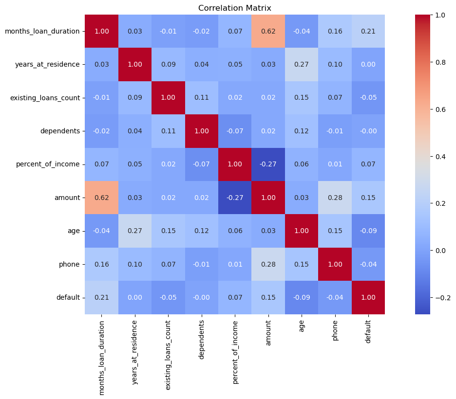

```python
numerical_columns = list(numerical_columns)
correlation_matrix = df_processed[numerical_columns + ["phone", "default"]].corr()
plt.figure(figsize=(16, 8))
sns.heatmap(correlation_matrix, annot=True, cmap='coolwarm', fmt='.2f', square=True)
plt.title('Correlation Matrix')
plt.show()
```

It seems that there isn't a significant correlation between the numerical variables and the default status. However, there are some weak correlations, particularly with variables related to the amount and duration of the loan. It's also worth noting a slight negative correlation with age and a slight positive correlation with the percentage of monthly income for default status. Additionally, there is an obvious relationship between the loan amount and the duration, with a notable correlation between the two.

**Distribution of variables with respect to default status**

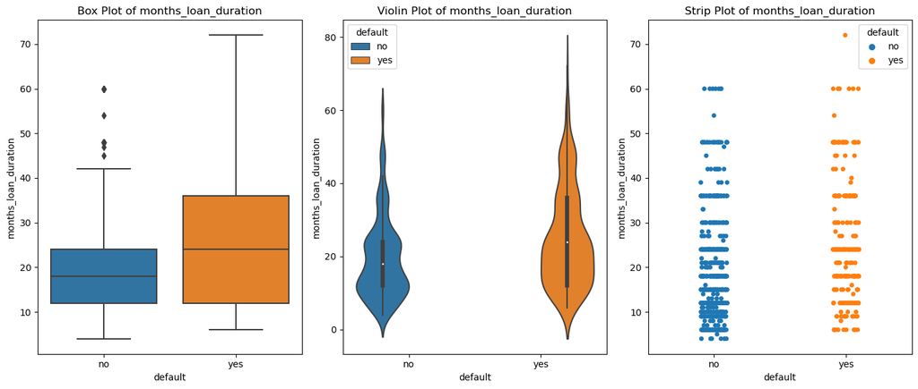

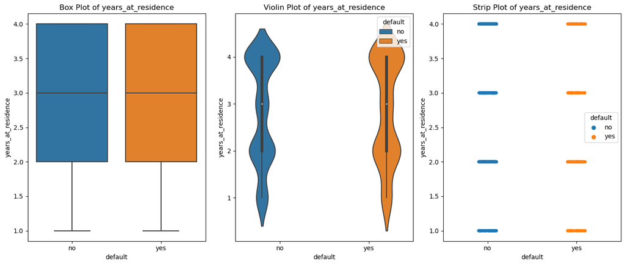

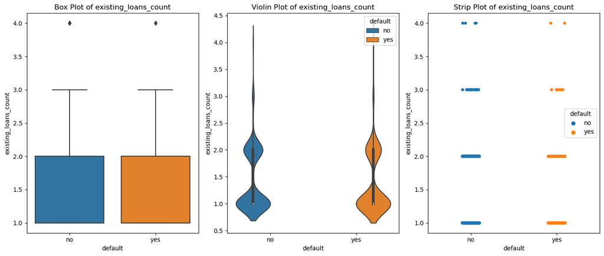

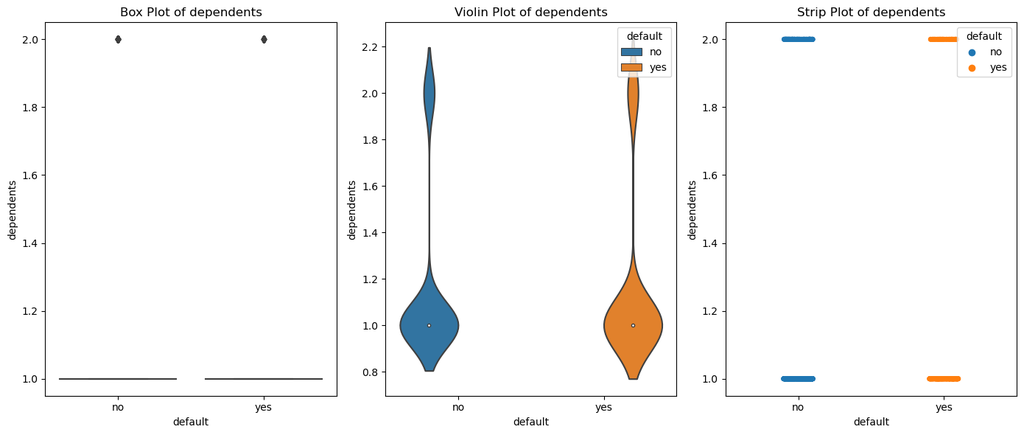

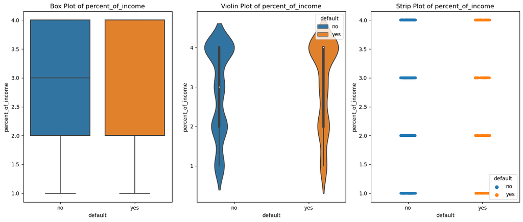

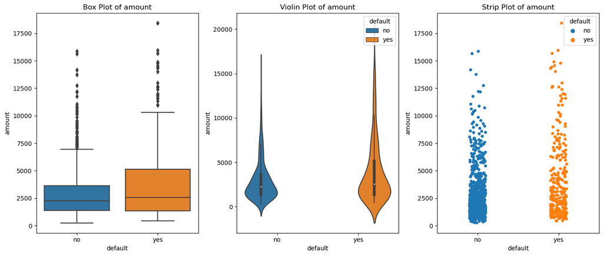

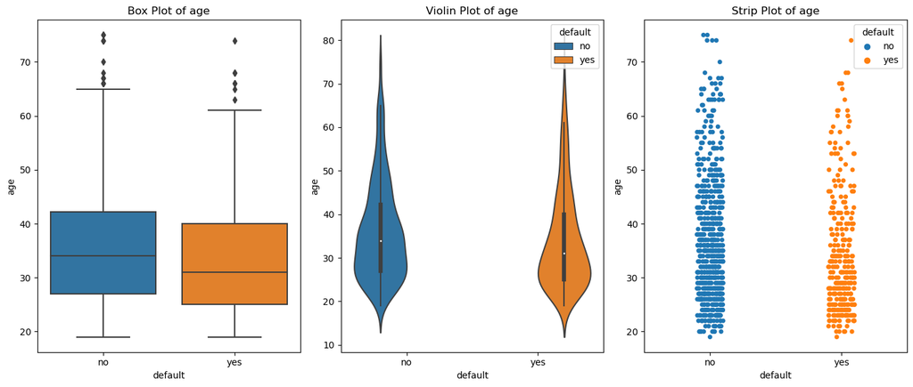

```python
# c = ["existing_loans_count", "dependents", "years_at_residence", "percent_of_income"]
for column in numerical_columns:
    fig, axs = plt.subplots(1, 3, figsize=(14, 6))
    sns.boxplot(x='default', y=column, data=df, ax=axs[0])
    axs[0].set_title(f'Box Plot of {column}')
    sns.violinplot(x='default', y=column, data=df, hue='default', ax=axs[1])
    axs[1].set_title(f'Violin Plot of {column}')
    # sns.kdeplot(data=df_processed, x=column, hue='default', fill=True, common_norm=False, alpha=0.5, ax=axs[2])
    # axs[2].set_title(f'Density Plot of {column}')
    sns.stripplot(data=df, x='default', y=column, hue='default', jitter=True, ax=axs[2])
    axs[2].set_title(f'Strip Plot of {column}')
    plt.tight_layout()
    plt.show()
```

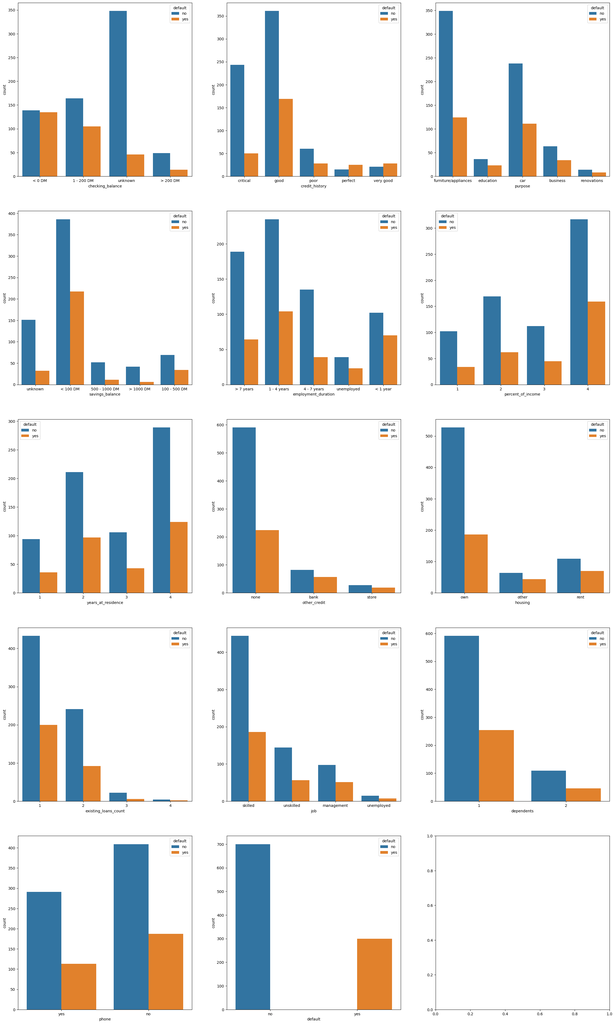

```python
fig, axs = plt.subplots(5, 3, figsize=(14*2, 6*8))
i = 0
for column in df.columns:
    if column in ["amount", "months_loan_duration", "age"]:
        continue
    # print(i // 3, i % 3)
    sns.countplot(data=df, x=column, hue='default', ax=axs[i // 3, i % 3])
    i += 1
plt.show()
```

```python
nominal_columns = ["checking_balance", "purpose", "savings_balance", "other_credit", "housing", "job", "phone", "default"]
ordinal_columns = ["credit_history", "employment_duration"]
numerical_columns = list(numerical_columns)
print("numerical_columns: ", numerical_columns)
print("ordinal_columns: ", ordinal_columns)
print("nominal_columns: ", nominal_columns)
```

```
numerical_columns:  ['months_loan_duration', 'years_at_residence', 'existing_loans_count', 'dependents', 'percent_of_income', 'amount', 'age']
ordinal_columns:  ['credit_history', 'employment_duration']
nominal_columns:  ['checking_balance', 'purpose', 'savings_balance', 'other_credit', 'housing', 'job', 'phone', 'default']
```

### Preprocessing for Model training

**Encoding Nominal columns**

```python
df_preprocessed = pd.get_dummies(data=df, columns=nominal_columns, dtype=int)
```

```python
df_preprocessed
```

|  | months_loan_duration | credit_history | amount | employment_duration | percent_of_income | years_at_residence | age | existing_loans_count | dependents | checking_balance_1 - 200 DM | ... | housing_own | housing_rent | job_management | job_skilled | job_unemployed | job_unskilled | phone_no | phone_yes | default_no | default_yes |
| --- | --- | --- | --- | --- | --- | --- | --- | --- | --- | --- | --- | --- | --- | --- | --- | --- | --- | --- | --- | --- | --- |
| 0 | 6 | critical | 1169 | > 7 years | 4 | 4 | 67 | 2 | 1 | 0 | ... | 1 | 0 | 0 | 1 | 0 | 0 | 0 | 1 | 1 | 0 |
| 1 | 48 | good | 5951 | 1 - 4 years | 2 | 2 | 22 | 1 | 1 | 1 | ... | 1 | 0 | 0 | 1 | 0 | 0 | 1 | 0 | 0 | 1 |
| 2 | 12 | critical | 2096 | 4 - 7 years | 2 | 3 | 49 | 1 | 2 | 0 | ... | 1 | 0 | 0 | 0 | 0 | 1 | 1 | 0 | 1 | 0 |
| 3 | 42 | good | 7882 | 4 - 7 years | 2 | 4 | 45 | 1 | 2 | 0 | ... | 0 | 0 | 0 | 1 | 0 | 0 | 1 | 0 | 1 | 0 |
| 4 | 24 | poor | 4870 | 1 - 4 years | 3 | 4 | 53 | 2 | 2 | 0 | ... | 0 | 0 | 0 | 1 | 0 | 0 | 1 | 0 | 0 | 1 |
| ... | ... | ... | ... | ... | ... | ... | ... | ... | ... | ... | ... | ... | ... | ... | ... | ... | ... | ... | ... | ... | ... |
| 995 | 12 | good | 1736 | 4 - 7 years | 3 | 4 | 31 | 1 | 1 | 0 | ... | 1 | 0 | 0 | 0 | 0 | 1 | 1 | 0 | 1 | 0 |
| 996 | 30 | good | 3857 | 1 - 4 years | 4 | 4 | 40 | 1 | 1 | 0 | ... | 1 | 0 | 1 | 0 | 0 | 0 | 0 | 1 | 1 | 0 |
| 997 | 12 | good | 804 | > 7 years | 4 | 4 | 38 | 1 | 1 | 0 | ... | 1 | 0 | 0 | 1 | 0 | 0 | 1 | 0 | 1 | 0 |
| 998 | 45 | good | 1845 | 1 - 4 years | 4 | 4 | 23 | 1 | 1 | 0 | ... | 0 | 0 | 0 | 1 | 0 | 0 | 0 | 1 | 0 | 1 |
| 999 | 45 | critical | 4576 | unemployed | 3 | 4 | 27 | 1 | 1 | 1 | ... | 1 | 0 | 0 | 1 | 0 | 0 | 1 | 0 | 1 | 0 |

1000 rows × 37 columns

**Encoding ordinal columns**

```python
from sklearn.preprocessing import OrdinalEncoder
ordinal_encoder = OrdinalEncoder(categories=[['critical', 'poor', 'good', 'very good', 'perfect'], ['unemployed', '< 1 year', '1 - 4 years', '4 - 7 years', '> 7 years']])
ordinal_df = df[ordinal_columns]
ordinal_df_encoded = pd.DataFrame(ordinal_encoder.fit_transform(ordinal_df), columns=ordinal_columns)
df_preprocessed = df_preprocessed.drop(columns=ordinal_columns)
df_preprocessed = pd.concat([df_preprocessed, ordinal_df_encoded], axis=1)
df_preprocessed
```

|  | months_loan_duration | amount | percent_of_income | years_at_residence | age | existing_loans_count | dependents | checking_balance_1 - 200 DM | checking_balance_< 0 DM | checking_balance_> 200 DM | ... | job_management | job_skilled | job_unemployed | job_unskilled | phone_no | phone_yes | default_no | default_yes | credit_history | employment_duration |
| --- | --- | --- | --- | --- | --- | --- | --- | --- | --- | --- | --- | --- | --- | --- | --- | --- | --- | --- | --- | --- | --- |
| 0 | 6 | 1169 | 4 | 4 | 67 | 2 | 1 | 0 | 1 | 0 | ... | 0 | 1 | 0 | 0 | 0 | 1 | 1 | 0 | 0.0 | 4.0 |
| 1 | 48 | 5951 | 2 | 2 | 22 | 1 | 1 | 1 | 0 | 0 | ... | 0 | 1 | 0 | 0 | 1 | 0 | 0 | 1 | 2.0 | 2.0 |
| 2 | 12 | 2096 | 2 | 3 | 49 | 1 | 2 | 0 | 0 | 0 | ... | 0 | 0 | 0 | 1 | 1 | 0 | 1 | 0 | 0.0 | 3.0 |
| 3 | 42 | 7882 | 2 | 4 | 45 | 1 | 2 | 0 | 1 | 0 | ... | 0 | 1 | 0 | 0 | 1 | 0 | 1 | 0 | 2.0 | 3.0 |
| 4 | 24 | 4870 | 3 | 4 | 53 | 2 | 2 | 0 | 1 | 0 | ... | 0 | 1 | 0 | 0 | 1 | 0 | 0 | 1 | 1.0 | 2.0 |
| ... | ... | ... | ... | ... | ... | ... | ... | ... | ... | ... | ... | ... | ... | ... | ... | ... | ... | ... | ... | ... | ... |
| 995 | 12 | 1736 | 3 | 4 | 31 | 1 | 1 | 0 | 0 | 0 | ... | 0 | 0 | 0 | 1 | 1 | 0 | 1 | 0 | 2.0 | 3.0 |
| 996 | 30 | 3857 | 4 | 4 | 40 | 1 | 1 | 0 | 1 | 0 | ... | 1 | 0 | 0 | 0 | 0 | 1 | 1 | 0 | 2.0 | 2.0 |
| 997 | 12 | 804 | 4 | 4 | 38 | 1 | 1 | 0 | 0 | 0 | ... | 0 | 1 | 0 | 0 | 1 | 0 | 1 | 0 | 2.0 | 4.0 |
| 998 | 45 | 1845 | 4 | 4 | 23 | 1 | 1 | 0 | 1 | 0 | ... | 0 | 1 | 0 | 0 | 0 | 1 | 0 | 1 | 2.0 | 2.0 |
| 999 | 45 | 4576 | 3 | 4 | 27 | 1 | 1 | 1 | 0 | 0 | ... | 0 | 1 | 0 | 0 | 1 | 0 | 1 | 0 | 0.0 | 0.0 |

1000 rows × 37 columns

```python
df_preprocessed.info()
```

```
<class 'pandas.core.frame.DataFrame'>
RangeIndex: 1000 entries, 0 to 999
Data columns (total 37 columns):
 #   Column                         Non-Null Count  Dtype
---  ------                         --------------  -----
 0   months_loan_duration           1000 non-null   int64
 1   amount                         1000 non-null   int64
 2   percent_of_income              1000 non-null   int64
 3   years_at_residence             1000 non-null   int64
 4   age                            1000 non-null   int64
 5   existing_loans_count           1000 non-null   int64
 6   dependents                     1000 non-null   int64
 7   checking_balance_1 - 200 DM    1000 non-null   int64
 8   checking_balance_< 0 DM        1000 non-null   int64
 9   checking_balance_> 200 DM      1000 non-null   int64
```

[output cut: 29 more lines]

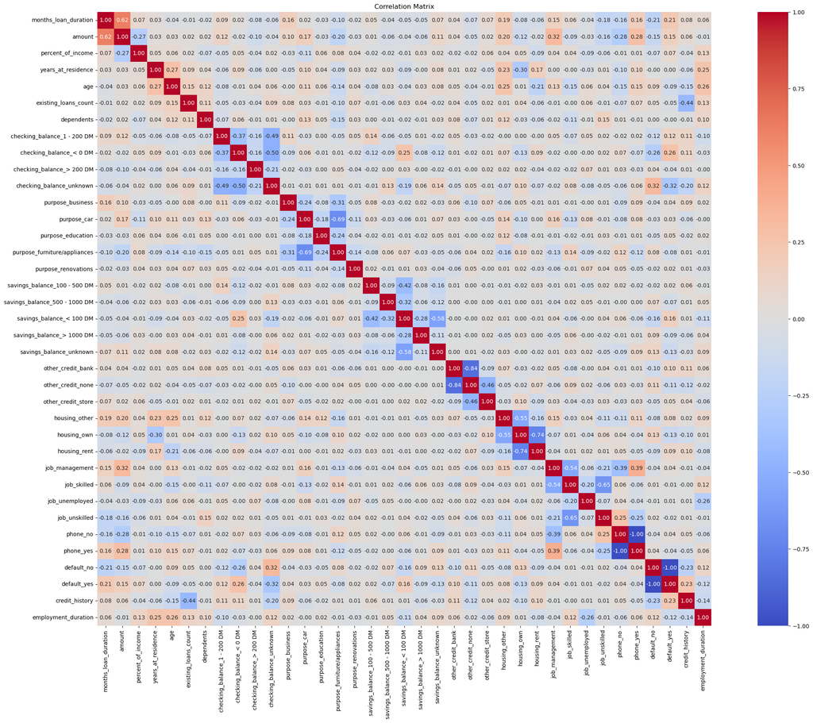

```python
correlation_matrix = df_preprocessed.corr()
plt.figure(figsize=(30, 20))
sns.heatmap(correlation_matrix, annot=True, cmap='coolwarm', fmt='.2f', square=True)
plt.title('Correlation Matrix')
plt.show()
```

```python
# Replacing default_yes with default for easier interpretation. Similarly phone_yes is replaced by phone
df_preprocessed["phone"] = df_preprocessed["phone_yes"]
df_preprocessed["default"] = df_preprocessed["default_yes"]
 # Removing extra columns to reduce curse of dimensionality. I am doing this manually to increase the interpretability of the model by removing the unknown column.
df_preprocessed = df_preprocessed.drop(columns=["default_yes", "phone_yes", "phone_no", "default_no", "checking_balance_unknown", "savings_balance_unknown", "other_credit_none", "housing_other", "job_unemployed", "purpose_renovations"])
```

```python
print(df_preprocessed.info())
df_preprocessed.to_csv('preprocessed_credit.csv', index=False)
df_preprocessed.head(10)
```

```
<class 'pandas.core.frame.DataFrame'>
RangeIndex: 1000 entries, 0 to 999
Data columns (total 29 columns):
 #   Column                         Non-Null Count  Dtype
---  ------                         --------------  -----
 0   months_loan_duration           1000 non-null   int64
 1   amount                         1000 non-null   int64
 2   percent_of_income              1000 non-null   int64
 3   years_at_residence             1000 non-null   int64
 4   age                            1000 non-null   int64
 5   existing_loans_count           1000 non-null   int64
 6   dependents                     1000 non-null   int64
 7   checking_balance_1 - 200 DM    1000 non-null   int64
 8   checking_balance_< 0 DM        1000 non-null   int64
 9   checking_balance_> 200 DM      1000 non-null   int64
```

[output cut: 22 more lines]

|  | months_loan_duration | amount | percent_of_income | years_at_residence | age | existing_loans_count | dependents | checking_balance_1 - 200 DM | checking_balance_< 0 DM | checking_balance_> 200 DM | ... | other_credit_store | housing_own | housing_rent | job_management | job_skilled | job_unskilled | credit_history | employment_duration | phone | default |
| --- | --- | --- | --- | --- | --- | --- | --- | --- | --- | --- | --- | --- | --- | --- | --- | --- | --- | --- | --- | --- | --- |
| 0 | 6 | 1169 | 4 | 4 | 67 | 2 | 1 | 0 | 1 | 0 | ... | 0 | 1 | 0 | 0 | 1 | 0 | 0.0 | 4.0 | 1 | 0 |
| 1 | 48 | 5951 | 2 | 2 | 22 | 1 | 1 | 1 | 0 | 0 | ... | 0 | 1 | 0 | 0 | 1 | 0 | 2.0 | 2.0 | 0 | 1 |
| 2 | 12 | 2096 | 2 | 3 | 49 | 1 | 2 | 0 | 0 | 0 | ... | 0 | 1 | 0 | 0 | 0 | 1 | 0.0 | 3.0 | 0 | 0 |
| 3 | 42 | 7882 | 2 | 4 | 45 | 1 | 2 | 0 | 1 | 0 | ... | 0 | 0 | 0 | 0 | 1 | 0 | 2.0 | 3.0 | 0 | 0 |
| 4 | 24 | 4870 | 3 | 4 | 53 | 2 | 2 | 0 | 1 | 0 | ... | 0 | 0 | 0 | 0 | 1 | 0 | 1.0 | 2.0 | 0 | 1 |
| 5 | 36 | 9055 | 2 | 4 | 35 | 1 | 2 | 0 | 0 | 0 | ... | 0 | 0 | 0 | 0 | 0 | 1 | 2.0 | 2.0 | 1 | 0 |
| 6 | 24 | 2835 | 3 | 4 | 53 | 1 | 1 | 0 | 0 | 0 | ... | 0 | 1 | 0 | 0 | 1 | 0 | 2.0 | 4.0 | 0 | 0 |
| 7 | 36 | 6948 | 2 | 2 | 35 | 1 | 1 | 1 | 0 | 0 | ... | 0 | 0 | 1 | 1 | 0 | 0 | 2.0 | 2.0 | 1 | 0 |
| 8 | 12 | 3059 | 2 | 4 | 61 | 1 | 1 | 0 | 0 | 0 | ... | 0 | 1 | 0 | 0 | 0 | 1 | 2.0 | 3.0 | 0 | 0 |
| 9 | 30 | 5234 | 4 | 2 | 28 | 2 | 1 | 1 | 0 | 0 | ... | 0 | 1 | 0 | 1 | 0 | 0 | 0.0 | 0.0 | 0 | 1 |

10 rows × 29 columns

#### 1. LogisticRegression Model

```python
models = {}
defaulter_count = np.sum(y_train)
total_count = len(y_train)
defaulter_weight = defaulter_count/total_count
# class_weight={0: defaulter_count, 1: total_count-defaulter_count}
class_weight={0: 1, 1: 1}

logistic_model = LogisticRegression(class_weight=class_weight, random_state=42)
logistic_model.fit(X_train_scaled, y_train)
model_name = "Logistic Regression"
models[model_name] = logistic_model
def get_classification_report(model, X, y, model_name="Logistic Regression", data_label="Training"):
    print(f"{model_name} - {data_label} Set Performance")
    y_pred = model.predict(X)
    accuracy = accuracy_score(y, y_pred)
    print(f"{data_label} Accuracy: {accuracy}")
    print(classification_report(y, y_pred))
    conf = confusion_matrix(y, y_pred)
    plt.figure(figsize=(4, 2))
    sns.heatmap(conf, annot=True, fmt='d',
                xticklabels=['No Default', 'Default'],
                yticklabels=['No Default', 'Default'])
    plt.title(f'{model_name} - Confusion Matrix ({data_label} Set)')
    plt.xlabel('Predicted')
    plt.ylabel('Actual')
    plt.show()


get_classification_report(logistic_model, X_train_scaled, y_train, model_name=model_name, data_label="Training")
get_classification_report(logistic_model, X_test_scaled, y_test, model_name=model_name, data_label="Test")
```

[output not shown]

#### 2. Linear Discriminant Analysis

```python
lda_model = LinearDiscriminantAnalysis()
lda_model.fit(X_train_scaled, y_train)
print("The coefficients are ", {column: value for column, value in zip(X_train.columns, lda_model.coef_[0])})
model_name = "Linear Discriminant Analysis"
models[model_name] = lda_model
get_classification_report(lda_model, X_train_scaled, y_train, model_name=model_name, data_label="Training")
get_classification_report(lda_model, X_test_scaled, y_test, model_name=model_name, data_label="Test")
```

[output not shown]

#### 3. Quadratic Discriminant Analysis

```python
qda_model = QuadraticDiscriminantAnalysis()
qda_model.fit(X_train_scaled, y_train)
model_name = "Quadratic Discriminant Analysis"
models[model_name] = qda_model
get_classification_report(qda_model, X_train_scaled, y_train, model_name=model_name, data_label="Training")
get_classification_report(qda_model, X_test_scaled, y_test, model_name=model_name, data_label="Test")
```

[output not shown]

#### 4. Gaussian Naive Bayes

```python
gnb_model = GaussianNB()
gnb_model.fit(X_train_scaled, y_train)
model_name = "Gaussian Naive Bayes"
models[model_name] = gnb_model
get_classification_report(gnb_model, X_train_scaled, y_train, model_name=model_name, data_label="Training")
get_classification_report(gnb_model, X_test_scaled, y_test, model_name=model_name, data_label="Test")
```

[output not shown]

#### 5. K-Nearest Neighbors (KNN)

```python
knn = KNeighborsClassifier()
param_grid = {
    'n_neighbors': range(3, 15),
}
grid_search = GridSearchCV(estimator=knn, param_grid=param_grid, cv=5, scoring='recall', n_jobs=-1, refit=True)
grid_search.fit(X_train_scaled, y_train)
best_params = grid_search.best_params_
print(f"The best parameter is {best_params}")
knn_model = grid_search.best_estimator_
model_name = "K-Nearest Neighbors (KNN)"
models[model_name] = knn_model
get_classification_report(knn_model, X_train_scaled, y_train, model_name=model_name, data_label="Training")
get_classification_report(knn_model, X_test_scaled, y_test, model_name=model_name, data_label="Test")
```

[output not shown]

#### 6. Support Vector Machine (SVM)

```python
param_grid = {
    'C': [1, 5, 10, 15, 20, 25],
    'kernel': ['linear', 'rbf', 'poly'],
    'gamma': ['scale', 'auto']
}
svm = SVC(class_weight=class_weight, random_state=42)
grid_search = GridSearchCV(svm, param_grid, cv=5, n_jobs=-1, scoring='recall', refit=True)
grid_search.fit(X_train_scaled, y_train)

print("Best Parameters:", grid_search.best_params_)
print("Best Score:", grid_search.best_score_)
svm_model = grid_search.best_estimator_
# print("Class weight:", svm_model.class_weight_)
model_name = "Support Vector Machine (SVM)"
models[model_name] = svm_model
get_classification_report(svm_model, X_train_scaled, y_train, model_name=model_name, data_label="Training")
get_classification_report(svm_model, X_test_scaled, y_test, model_name=model_name, data_label="Test")
```

[output not shown]

#### 7. Random Forest Classifier

```python
param_grid = {
    'n_estimators': [50, 100, 200, 300, 400],
    'max_depth': [None, 20, 25],
    'min_samples_split': [2, 3, 4, 5, 6],
    'min_samples_leaf': [1, 2, 3, 4, 5]
}

rf_model = RandomForestClassifier(random_state=42)
grid_search = GridSearchCV(estimator=rf_model, param_grid=param_grid, cv=5, n_jobs=-1, scoring = 'recall', refit=True)
grid_search.fit(X_train_scaled, y_train)
print("Best Parameters:", grid_search.best_params_)
print("Best Score:", grid_search.best_score_)
rf_model = grid_search.best_estimator_
model_name = "Random Forest Classifier"
models[model_name] = rf_model
get_classification_report(rf_model, X_train_scaled, y_train, model_name=model_name, data_label="Training")
get_classification_report(rf_model, X_test_scaled, y_test, model_name=model_name, data_label="Test")
```

[output not shown]

#### 8. Gradient Boosting Machines (GBM)

```python
param_grid = {
    'max_depth': [3, 4, 5, 6],
    'max_features': [5, 6, 7, 8],
    'min_samples_leaf': [2, 3, 4, 5],
    'min_samples_split': [9, 10, 11, 12]
}
gb_clf = GradientBoostingClassifier(random_state=42)
grid_search = GridSearchCV(gb_clf, param_grid, cv=5, n_jobs=-1, scoring = 'recall', refit=True)
grid_search.fit(X_train_scaled, y_train)
print("Best Parameters:", grid_search.best_params_)
print("Best Score:", grid_search.best_score_)
gbm_model = grid_search.best_estimator_
model_name = "Gradient Boosting Classifier"
models[model_name] = gbm_model
get_classification_report(gbm_model, X_train_scaled, y_train, model_name=model_name, data_label="Training")
get_classification_report(gbm_model, X_test_scaled, y_test, model_name=model_name, data_label="Test")
```

[output not shown]

#### 9. AdaBoost

```python
param_grid = {
    'n_estimators': [35, 40, 45, 50, 100, 150],
    'learning_rate': [0.1, 0.5, 1.0, 2.0, 3.0, 4.0, 5.0]
}
ada_clf = AdaBoostClassifier(random_state=42)
grid_search = GridSearchCV(ada_clf, param_grid, cv=5, n_jobs=-1, scoring = 'recall', refit=True)
grid_search.fit(X_train_scaled, y_train)
print("Best Parameters:", grid_search.best_params_)
print("Best Score:", grid_search.best_score_)
adaboost_model = grid_search.best_estimator_
model_name = "AdaBoost Classifier"
models[model_name] = adaboost_model
get_classification_report(adaboost_model, X_train_scaled, y_train, model_name=model_name, data_label="Training")
get_classification_report(adaboost_model, X_test_scaled, y_test, model_name=model_name, data_label="Test")
```

[output not shown]

#### 10. XGBoost

```python
xgboost_model = XGBClassifier(objective= 'binary:logistic', seed=42, scale_pos_weight=1)
parameters = {
    'n_estimators':range(227, 230),
    'learning_rate': [0.01, 0.1, 0.2],
    'min_child_weight': [3, 4, 5],
    'max_depth': [3, 5, 7],
    'gamma': [0, 0.1, 0.2],
    'subsample': [0.8, 0.9, 1],
    'colsample_bytree': [0.5, 0.7, 1],
    'reg_alpha': [0, 0.01, 0.02]
}
grid_search = GridSearchCV(estimator=xgboost_model, param_grid=parameters, cv=5, scoring='recall', n_jobs=-1, refit=True)
grid_search.fit(X_train_scaled, y_train)
print("Best Parameters:", grid_search.best_params_)
print("Best Score:", grid_search.best_score_)
xgboost_model = grid_search.best_estimator_
model_name = "XGBoost Classifier"
models[model_name] = xgboost_model
get_classification_report(xgboost_model, X_train_scaled, y_train, model_name=model_name, data_label="Training")
get_classification_report(xgboost_model, X_test_scaled, y_test, model_name=model_name, data_label="Test")
```

[output not shown]

#### 11. LightGBM

```python
from lightgbm import LGBMClassifier
model = LGBMClassifier(objective='binary', random_state=42, n_jobs=-1)
parameters = {
    'n_estimators': [150, 155, 200],
    'num_leaves': [23, 24, 25],
    'learning_rate': [0.01, 0.1, 0.2, 0.3],
    # 'min_child_weight': [1, 3, 5],
    'max_depth': [-1, 4, 5, 6],
    # 'min_child_samples': [10, 20, 30],
    # 'subsample': [0.5, 0.7, 1],
    # 'colsample_bytree': [0.5, 0.7, 1],
    'reg_alpha': [0, 0.1, 0.5]
}
grid_search = GridSearchCV(estimator=model, param_grid=parameters, cv=5, scoring='recall', n_jobs=-1, refit=True)
grid_search.fit(X_train_scaled, y_train)
print("Best Parameters:", grid_search.best_params_)
print("Best Score:", grid_search.best_score_)
lightgbm_model = grid_search.best_estimator_
model_name = "LightGBM Classifier"
models[model_name] = lightgbm_model
get_classification_report(lightgbm_model, X_train_scaled, y_train, model_name=model_name, data_label="Training")
get_classification_report(lightgbm_model, X_test_scaled, y_test, model_name=model_name, data_label="Test")
```

[output not shown]

#### 12. Catboost

```python
!pip install catboost
```

```python
from catboost import CatBoostClassifier, Pool
X = df.drop(columns=['default'])
y = df['default']
X_train, X_test, y_train, y_test = train_test_split(X, y, test_size=0.2, random_state=42)

categorical_features = ["checking_balance", "credit_history", "purpose", "savings_balance", "employment_duration", "other_credit", "housing", "job", "phone"]
parameters = {
    'learning_rate': [0.01, 0.1, 0.2],
    'depth': [4, 6, 8],
    'l2_leaf_reg': [1, 3, 5],
    'border_count': [32, 64, 128],
    'iterations': [100, 200, 300]
}
scale_pos_weight = len(y_train[y_train=='no']) / len(y_train[y_train=='yes'])
print(scale_pos_weight)
# y_train = y_train.replace({'no': 0, 'yes': 1}).astype(int)
# train_pool = Pool(data=X_train, label=y_train)

catboost_model = CatBoostClassifier(iterations=150, depth=4, learning_rate=0.1, cat_features=categorical_features,
                           loss_function='Logloss', scale_pos_weight=scale_pos_weight, random_seed=42)
# catboost_model = CatBoostClassifier(loss_function='Logloss', , cat_features=categorical_columns, random_seed=42)
# grid_search = GridSearchCV(estimator=catboost_model, param_grid=parameters, cv=5, scoring='recall', n_jobs=-1)
catboost_model.fit(X_train, y_train)

# print("Best Parameters:", grid_search.best_params_)
# print("Best Score:", grid_search.best_score_)
# catboost_model = grid_search.best_estimator_
models.append(catboost_model)
get_classification_report(catboost_model, X_train, y_train, model_name="CatBoost", data_label="Training")
get_classification_report(catboost_model, X_test, y_test, model_name="CatBoost", data_label="Test")
```

[output not shown]

```python
models
```